# Genome-wide methylation analysis report

# Genome-wide methylation analysis report

- study: Pleural cfDNAm analysis of smoke_current_nevervariable
- author: Paul Yousefi
- date: 08 October, 2026

## Parameters

```
## $sig.threshold
## [1] 2.121143e-07
##
## $max.plots
## [1] 10
##
## $qq.inflation.method
## [1] "median"
##
## $practical.threshold
## [1] 3.836664e-05
```

## Sample characteristics

For continuous or ordinal variables, the “mean” column provides the mean and the “sd/%” column the standard deviation of the variable. For categorical variables, the “mean” column provides the number of samples with the given “value” and the “sd/%” column the percentage of samples with the given “value”.

| variable | value | mean | sd.. |
| --- | --- | --- | --- |
| smoke_current_never |  | 0.5047619 | 0.5023753 |
| sv1 |  | 7.062157e-18 | 0.09805807 |
| sv2 |  | -4.259624e-18 | 0.09805807 |
| sv3 |  | 5.867857e-18 | 0.09805807 |
| sv4 |  | -1.690581e-18 | 0.09805807 |
| sv5 |  | -3.915763e-18 | 0.09805807 |
| sv6 |  | 5.64424e-18 | 0.09805807 |
| sv7 |  | 5.543238e-17 | 0.09805807 |
| sv8 |  | 4.176955e-15 | 0.09805807 |
| sv9 |  | 2.309868e-13 | 0.09805807 |
| sv10 |  | 7.152795e-13 | 0.09805807 |

## Covariate associations

### Covariate sv1

statistics

| var1 | var2 | F | p-value | R | p-value |
| --- | --- | --- | --- | --- | --- |
| smoke_current_never | sv1 | 0.0001785 | 0.9893662 | -0.0125693 | 0.8987343 |

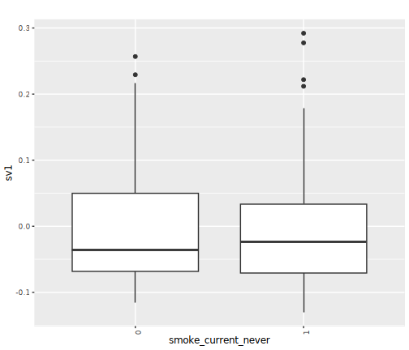

### Covariate sv2

statistics

| var1 | var2 | F | p-value | R | p-value |
| --- | --- | --- | --- | --- | --- |
| smoke_current_never | sv2 | 0.731782 | 0.3942917 | -0.0163401 | 0.8685953 |

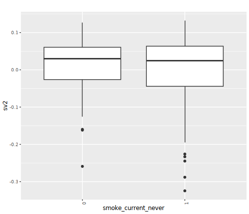

### Covariate sv3

statistics

| var1 | var2 | F | p-value | R | p-value |
| --- | --- | --- | --- | --- | --- |
| smoke_current_never | sv3 | 1.294698 | 0.2578239 | -0.044621 | 0.6512822 |

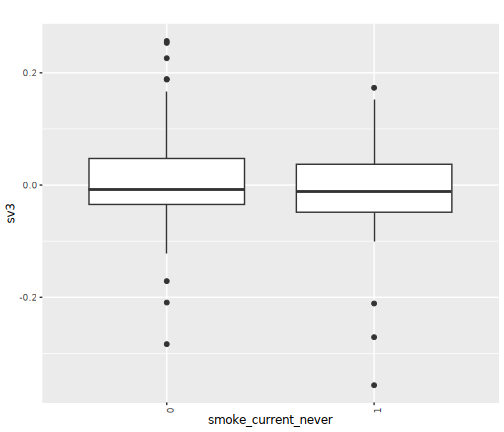

### Covariate sv4

statistics

| var1 | var2 | F | p-value | R | p-value |
| --- | --- | --- | --- | --- | --- |
| smoke_current_never | sv4 | 0.1027501 | 0.7492035 | -0.055305 | 0.575239 |

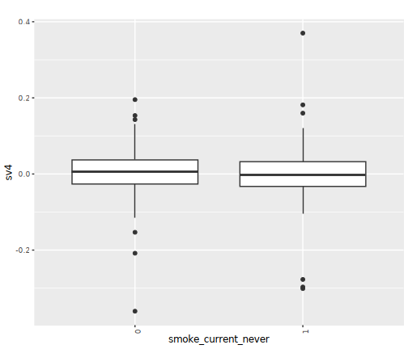

### Covariate sv5

statistics

| var1 | var2 | F | p-value | R | p-value |
| --- | --- | --- | --- | --- | --- |
| smoke_current_never | sv5 | 0.0909286 | 0.7636079 | 0.0144547 | 0.8836441 |

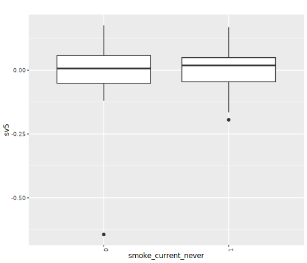

### Covariate sv6

statistics

| var1 | var2 | F | p-value | R | p-value |
| --- | --- | --- | --- | --- | --- |
| smoke_current_never | sv6 | 0.1550371 | 0.6945814 | -0.1590018 | 0.1052099 |

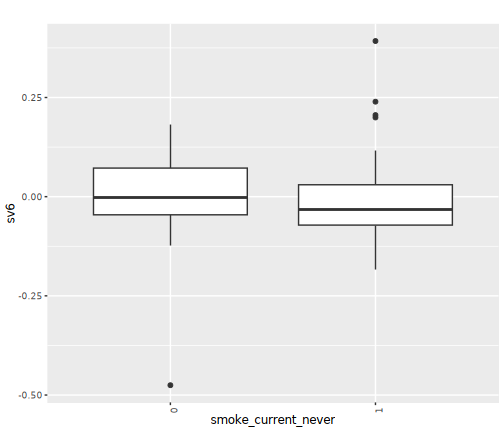

### Covariate sv7

statistics

| var1 | var2 | F | p-value | R | p-value |
| --- | --- | --- | --- | --- | --- |
| smoke_current_never | sv7 | 0.0284862 | 0.8663017 | -0.0025139 | 0.9796952 |

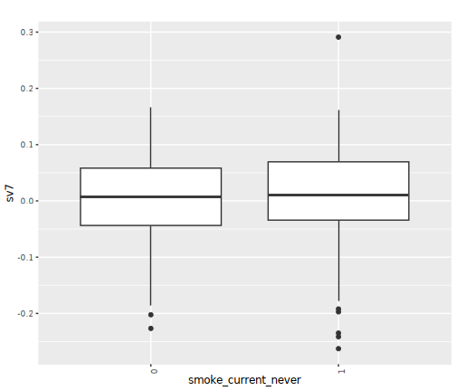

### Covariate sv8

statistics

| var1 | var2 | F | p-value | R | p-value |
| --- | --- | --- | --- | --- | --- |
| smoke_current_never | sv8 | 2.094825 | 0.1508354 | -0.1860258 | 0.0574333 |

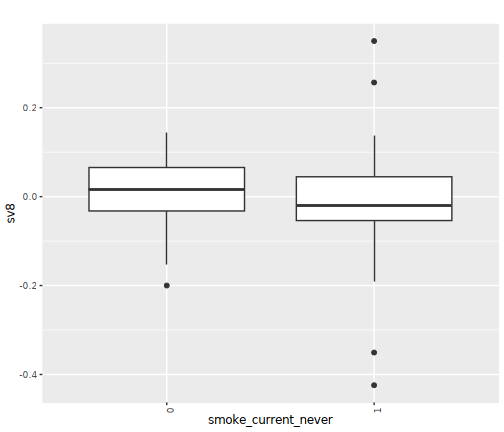

### Covariate sv9

statistics

| var1 | var2 | F | p-value | R | p-value |
| --- | --- | --- | --- | --- | --- |
| smoke_current_never | sv9 | 0.0717273 | 0.7893739 | 0.1131238 | 0.2505599 |

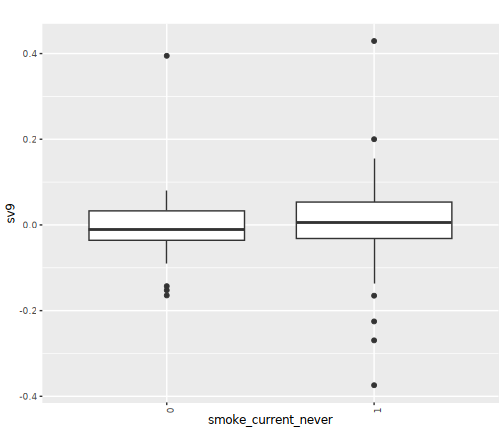

### Covariate sv10

statistics

[output not shown]

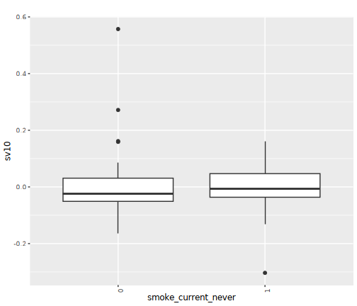

## QQ plots

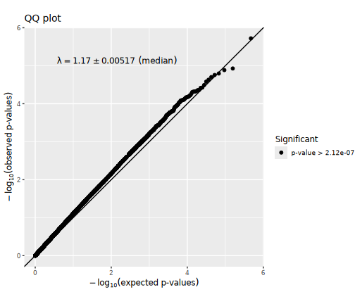

## Manhattan plots

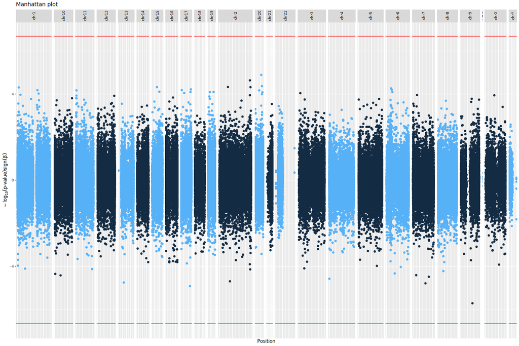

## Significant CpG sites

There were 0 CpG sites with association p-values < 2.1211427 × 10<sup>-7</sup>. These are listed in the file associations.csv.

Below are the 10 CpG sites with association p-values < 3.8366639 × 10<sup>-5</sup> in the regression model.

|  | chromosome | position | estimate | p.value | p.adjust |
| --- | --- | --- | --- | --- | --- |
| cg16031567 | chr10 | 46195673 | -0.0438939 | 3.75e-05 | 1.0000000 |
| cg06447378 | chr13 | 39358893 | -0.0810655 | 1.75e-05 | 1.0000000 |
| cg13167372 | chr17 | 70536814 | -0.0705123 | 1.18e-05 | 1.0000000 |
| cg04298936 | chr2 | 234257912 | 0.0735032 | 2.33e-05 | 1.0000000 |
| cg11404492 | chr7 | 95665002 | -0.0922619 | 1.60e-05 | 1.0000000 |
| cg13866899 | chr9 | 89275685 | -0.0845314 | 1.90e-06 | 0.4478774 |
| cg06527154 | chr7 | 121566048 | -0.0518991 | 3.23e-05 | 1.0000000 |
| cg17646721 | chr2 | 80197796 | -0.0777643 | 1.99e-05 | 1.0000000 |
| cg23595927 | chr4 | 671851 | -0.0823659 | 2.62e-05 | 1.0000000 |
| cg01319874 | chr20 | 46397228 | 0.0979659 | 1.30e-05 | 1.0000000 |

Plots of these sites follow, one for each covariate set. “p[lm]” denotes the p-value obtained using a linear model and “p[beta]” the p-value obtained using beta regression.

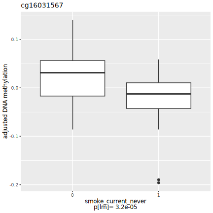

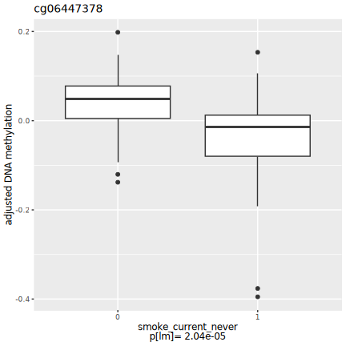

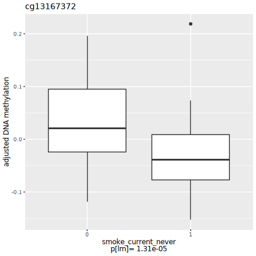

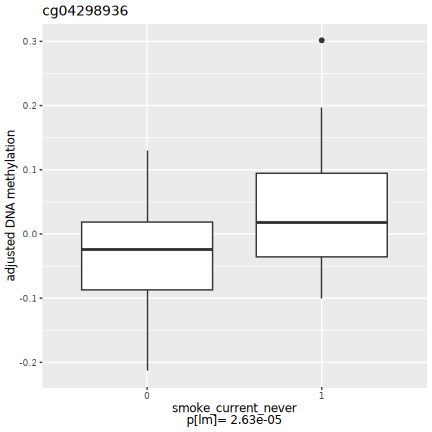

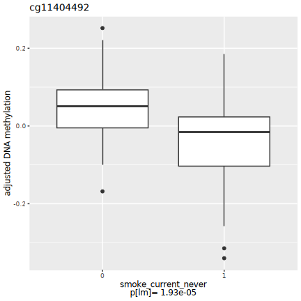

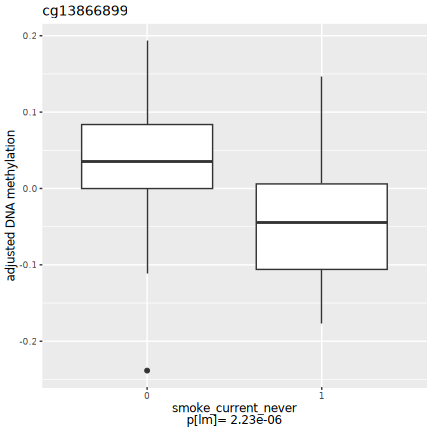

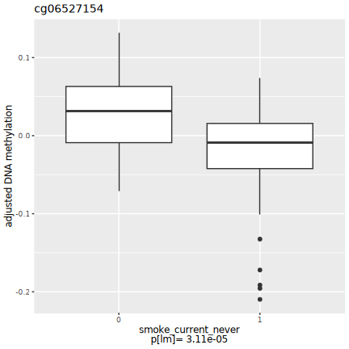

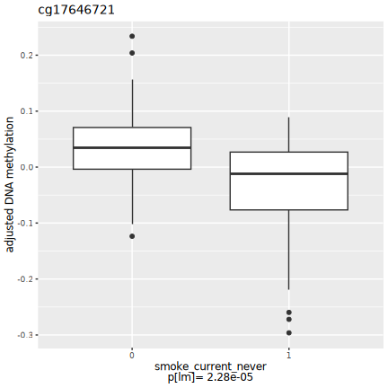

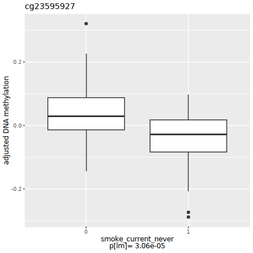

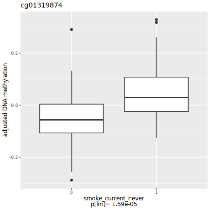

## Selected CpG sites

Number of CpG sites selected: 0.

| chromosome | position | estimate | p.value | p.adjust |
| --- | --- | --- | --- | --- |